# Project 2A: Galton Data

James Kolesar

Tuesday, December 07, 2021 @ 01:03 PM

## Setup

### Packages Used

```r
library(readr)
library(dplyr)
library(DT)
library(ggplot2)
```

### Datasets Used

```r
data_main = read_csv('https://raw.githubusercontent.com/STAT-JET-ASU/Datasets/master/Instructor/galtonfamiliesmain.csv')
```

```r
data_sub = read_csv('https://raw.githubusercontent.com/STAT-JET-ASU/Datasets/master/Instructor/galtonfamiliessub.csv')
```

### Collaborators

None :)

## Visualizations

### Background of the Data

Francis Galton, a cousin of Charles Darwin, studied the relationship between parent heights and the heights of their offspring. His pioneering [1886 article](https://galton.org/essays/1880-1889/galton-1886-jaigi-regression-stature.pdf) is the first appearance of regression analysis in print. He originated many statistical terms and concepts, including regression, correlation, deviate, quartile, and percentile, plus median for the midpoint of a distribution. The `galtonheightdata` dataset was [created under the direction of Dr. James A. Hanley](http://www.medicine.mcgill.ca/epidemiology/hanley/galton/) using Galton’s [original paper notebooks](http://www.medicine.mcgill.ca/epidemiology/hanley/galton/notebook/index.html) containing the measurement data. You can access the `galtonfamiliesmain.csv` and `galtonfamiliessub.csv` datasets from their [description](https://stat-jet-asu.github.io/Datasets/InstructorDescriptions/galtonheightdata.html) page, which also contains variable definitions.

### Create Analysis Datasets

#### Dataset #1

Load the `galtonfamiliesmain.csv` and `galtonfamiliessub.csv` datasets above under the **Setup** header and use `glimpse()` to explore their structures. Use your code from Project 1 and/or draw from the Project 1 solutions to assemble a dataset below that meets the following criteria. Use `datatable()` from the DT package to display the result.

- contains these variables:
  - `familyid` = ID number of the family, with `136A` recoded as `205`
  - `num_children`= the number of children in the family
  - `father_ht` = the height of the father
  - `mother_ht` = the “transmuted” (per Galton) height of the mother
  - `midparent` = the average of the parents’ heights
  - `child_sex`= whether the child is a son or a daughter, all lower case
  - `child_ht` = the height of the child with daughter heights “transmuted”
- is arranged according to:
  - ascending order of familyid
  - sons before daughters within family
  - in order of height within each sex of child

```r
new_data_sub = data_sub %>%
   transmute(FamilyID, Children, Father = FatherR + 60, Mother = MotherR + 60, Child, Height = HeightR + 60)

Galton_dataset_1 = data_main %>%
   mutate(FamilyID = as.numeric(ifelse(FamilyID == "136A", 205, FamilyID))) %>%
   bind_rows(new_data_sub) %>%
   mutate(Mother = 1.08*Mother, Height = ifelse(Child == "Son", Height, Height*1.08), midparent = (Father+Mother)/2, Child = tolower(Child)) %>%
   rename(familyid = FamilyID, num_children = Children, father_ht = Father, mother_ht = Mother, child_sex = Child, child_ht = Height) %>%
   arrange(familyid, desc(child_sex), child_ht)

datatable(Galton_dataset_1)
```

|  | familyid | num_children | father_ht | mother_ht | child_sex | child_ht | midparent |
| --- | --- | --- | --- | --- | --- | --- | --- |
| 1 | 1 | 4 | 78.5 | 72.36 | son | 73.2 | 75.43 |
| 2 | 1 | 4 | 78.5 | 72.36 | daughter | 74.52 | 75.43 |
| 3 | 1 | 4 | 78.5 | 72.36 | daughter | 74.52 | 75.43 |
| 4 | 1 | 4 | 78.5 | 72.36 | daughter | 74.736 | 75.43 |
| 5 | 2 | 4 | 75.5 | 71.82 | son | 72.5 | 73.66 |
| 6 | 2 | 4 | 75.5 | 71.82 | son | 73.5 | 73.66 |
| 7 | 2 | 4 | 75.5 | 71.82 | daughter | 70.74 | 73.66 |
| 8 | 2 | 4 | 75.5 | 71.82 | daughter | 70.74 | 73.66 |
| 9 | 3 | 2 | 75 | 69.12 | son | 71 | 72.06 |
| 10 | 3 | 2 | 75 | 69.12 | daughter | 73.44 | 72.06 |

[output cut: 924 more lines]

#### Dataset #2

Select the variables `familyid` and `num_children` and reduce the dataset so that it contains only one row per family. Again, use `datatable()` from the DT package to display the result.

```r
Galton_dataset_2 = Galton_dataset_1 %>%
   select(familyid, num_children) %>%
   group_by(familyid) %>%
   summarize(familyid = mean(familyid), num_children = mean(num_children))

datatable(Galton_dataset_2)
```

|  | familyid | num_children |
| --- | --- | --- |
| 1 | 1 | 4 |
| 2 | 2 | 4 |
| 3 | 3 | 2 |
| 4 | 4 | 5 |
| 5 | 5 | 6 |
| 6 | 6 | 1 |
| 7 | 7 | 6 |
| 8 | 8 | 3 |
| 9 | 9 | 1 |
| 10 | 10 | 1 |

[output cut: 195 more lines]

### Part 1: Parent/Child Heights

#### Galton’s Visualization

In his original paper (linked above), Galton created several tables and diagrams. His “Diagram Based on Table 1” of them is similar in concept to a scatterplot. Rather than dots, he grouped/tabulated the data, and then used the count of how many people were grouped at the coordinate pairs in his grid, with child as the x-axis and mid-parent as the y-axis. There are two scales: inches and deviations from 68.25 inches.

#### Updated Scatterplot #1

Create a scatterplot of child height (x-axis) versus mid-parent height (y-axis). Ordinarily, we might reverse the axes here because analysts would be more likely to model child height as a function of parent height, but we want to be able to compare the updated plot to Galton’s original. Make your dots larger than the default and adjust transparency (`alpha`) to correct for overplotting and help show the density of points.

Also include the following.

- use `color` in the `aes` to differentiate sons versus daughters
- use `scale_color_manual()` to choose two informative colors
- scale both axes so that there is a tick mark at every whole inch
- use `coord_fixed()` so that the axes have the same unit spacing
- add better x- and y-axis labels, including the units of measure
- add an informative title (you may optionally include a subtitle)
- add `color =` to `labs()` to set the legend title to `"gender of child"`
- use `theme_linedraw()` to add some additional plot formatting
- use `theme()` to move the legend to the bottom of the scatterplot

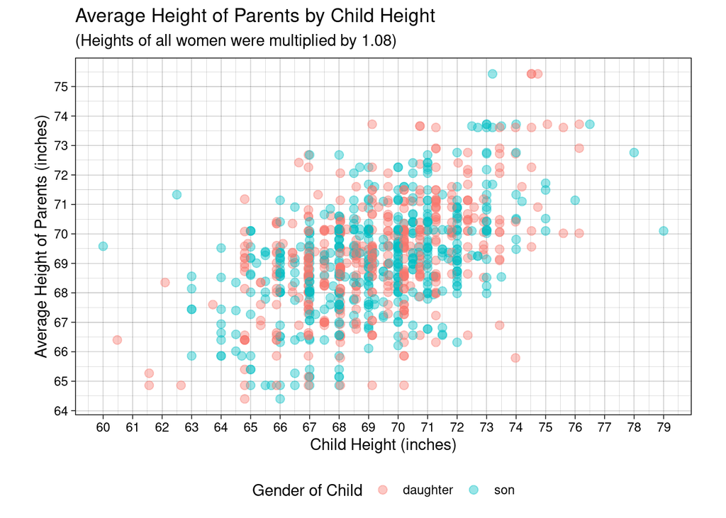

```r
#It should be noted that I actually really enjoy the default colors used by ggplot, so I just used them in my scale_color_manual() call.
ggplot(data = Galton_dataset_1, aes(x = child_ht, y = midparent, color = child_sex)) +
   geom_point(alpha = 0.4, size = 2.5) +
   scale_x_continuous(breaks = seq(60, 79, by = 1)) +
   scale_y_continuous(breaks = seq(64, 75, by = 1)) +
   coord_fixed() +
   labs(x = "Child Height (inches)", y = "Average Height of Parents (inches)", title = "Average Height of Parents by Child Height", color = "Gender of Child", subtitle = "(Heights of all women were multiplied by 1.08)") +
   theme_linedraw() +
   theme(legend.position = "bottom") +
   scale_color_manual(values = c('#F8766D','#00BFC4'))
```

#### Updated Scatterplot #2

Remove the color coding for sons versus daughters from your plot, as well as any other coding related to it. Instead, choose n single color for the points and adjust both `size` and transparency (`alpha`) as needed to correct for overplotting and help show the density of points. Reset the `aes` so child height is the `y` variable and midparent height is the `x` variable. Add a fitted *straight* line to the plot. Update your `labs` accordingly.

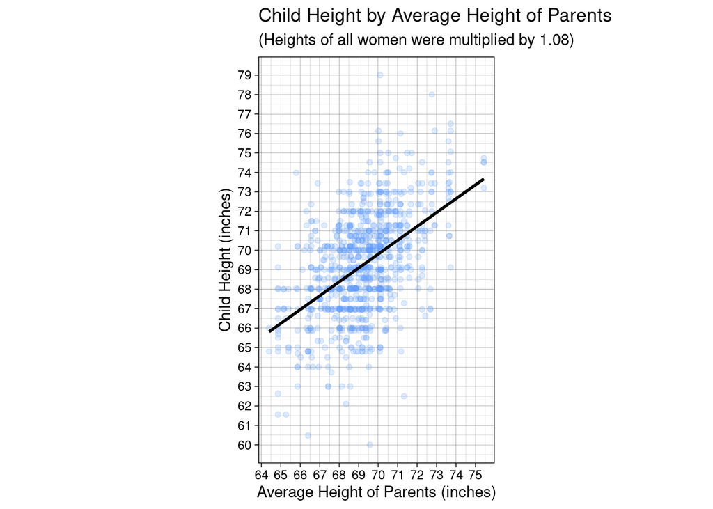

```r
ggplot(data = Galton_dataset_1, aes(x = midparent, y = child_ht)) +
   geom_point(alpha = 0.2, size = 1.5, color = "#619CFF") +
   scale_y_continuous(breaks = seq(60, 79, by = 1)) +
   scale_x_continuous(breaks = seq(64, 75, by = 1)) +
   coord_fixed() +
   labs(x = "Average Height of Parents (inches)", y = "Child Height (inches)", title = "Child Height by Average Height of Parents", color = "Gender of Child", subtitle = "(Heights of all women were multiplied by 1.08)") +
   theme_linedraw() +
   geom_smooth(method = lm, color = "black", se = FALSE)
```

```r
?geom_smooth
```

### Part 2: Number of Children

Create a barplot to show the distribution of the number of children per family. Set the bars to something other than the default `width`. Scale the x-axis so that there is a tick mark for each bar. Choose appropriate colors, labels, themes, and/or and other types of formatting that you feel will enhance the meaning or visual appearance of the plot.

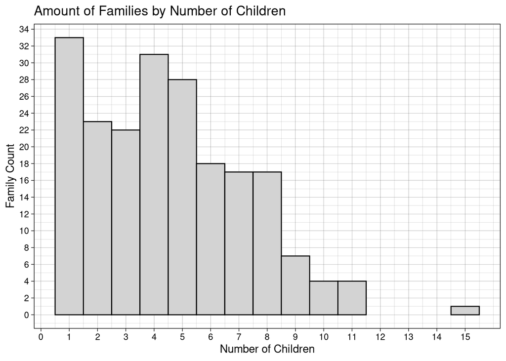

```r
ggplot(data = Galton_dataset_2, aes(x = num_children)) +
   geom_bar(width = 1, color = "black", fill = "light grey") +
   scale_x_continuous(breaks = seq(0, 15, by = 1)) +
   scale_y_continuous(breaks = seq(0, 35, by = 2)) +
   labs(x = "Number of Children", y = "Family Count", title = "Amount of Families by Number of Children") +
   theme_linedraw()
```

## Questions

**Question 1:** Do you think that your scatterplots are an improvement over Galton’s original diagram? Are there any modifications and/or additions you would make to enhance the clarity or usefulness of your plots?

**ANSWER**

Obvious props to Galton for being the data-analysis trailblazer that he was, but plots have definitely come a long way since his time. The biggest improvement between Galton’s plots and the ones made during this project is the clarity of the density of points. Granted, without being able to adjust an alpha level it’s much more difficult to visually represent multiple data points falling onto the same coordinate point, but some sort of color gradient or size factor could’ve been applied to the numbers he threw onto the paper. The rudimentary groupings also lead to a bit of necessary clutter around the axes, although to Galton’s credit it’s still quite readable despite being pretty packed. In terms of modifications, whenever dealing with relatively discrete data where certain coordinates will have multiple data points, my go-to in R is to apply some sort of jitter effect to my plot. Alpha works alright on its own, especially when we aren’t dealing with multiple thousands of data points, but I think when it’s combined with jitter it winds up adding much more clarity regarding density.

**Question 2:** Explain the rationale behind the choices you made when creating your scatterplots and barplot, such as size, color, transparency, or other features. What motivated your decisions?

**ANSWER**

**Question 3:** Considering best practices, how does using `coord_fixed()` enhance the authenticity of the information shown in the scatterplots, such as the relationship and spread of the data?

**ANSWER**

One of the oldest tricks in the book in terms of data manipulation is to alter the scale of one or both of our axes in order to emphasize or deemphasize the effect of one on the other. Sometimes this scaling is necessary, like if we were comparing SAT score to college GPA, two values with wildly different scales, however in this case we were examining the relationship between the heights of two adults (for all intents and purposes) so matching the scale of our axes makes total sense. In terms of authenticity, removing any sort of manipulative tactics we have at our disposal as statisticians means any relationships we see in our data visualizations are that much more likely to be real, which is exactly what we’re doing by applying `coord_fixed()` to our plot.